# Psychology and Human Behavior

Module 07 — Explaining behavior and choosing a response

NRES 315: Human Dimensions of Fish and Wildlife Management

October 7, 2026

## Why might someone care but still not act?

On Monday, we separated three parts of mental life:

- Cognition: what a person thinks or believes.
- Conation: the person’s motivation and intention to act.
- Affect: what a person feels.

Today we connect these to **specific actions** and to the conditions that make those actions easier or harder.

Source: Chapter 8, §§8.3–8.4

## What you should be able to explain

By the end of class, you should be able to:

- specify an observable behavior using TACT;
- explain how beliefs, norms, and control shape intention and action;
- explain why cooperation depends on both individuals and their social setting;
- distinguish emotions, motivations, and satisfaction; and
- choose a response and a measure that fit the behavior you want to change.

Source: Chapter 8, §§8.4–8.5

## What a framework helps us see

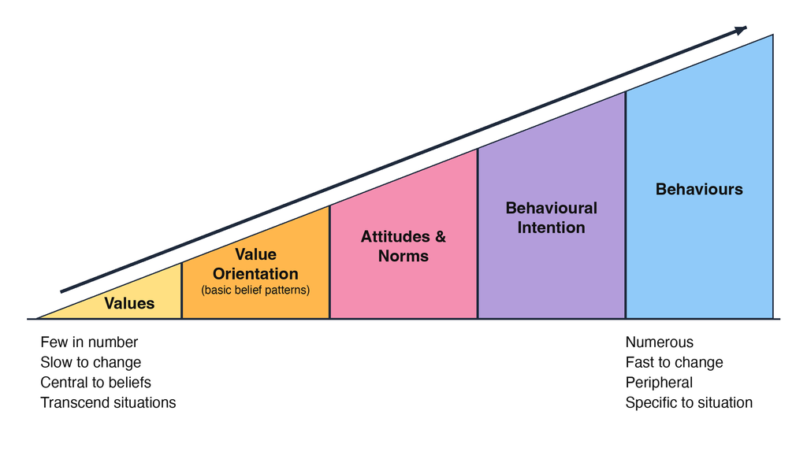

Monday’s hierarchy connected broad values to specific decisions. Today’s frameworks explain **different parts of that connection**.

Source: Chapter 8, §8.4.1, Figure 8.1, and Box 8.5

## Define the behavior first

What, exactly, do we want a person to do?

A broad concern about conservation is not yet an action we can observe.

Source: Chapter 8, §8.4.3 and Box 8.5

## Start with the boating problem

In **this Friday’s Thornapple Lake teaching case (October 9)**, the agency wants to limit the spread of invasive mussels to other waters.

One action it can target is draining boats before they leave the lake.

“Boaters should care more” leaves us guessing about what they should do.

Source: Chapter 8, §8.4.3; Friday Case Brief 07, §§1–2

## TACT: make the behavior observable

Specify the draining behavior with four questions:

| Letter | Question | Weak | Strong |
| --- | --- | --- | --- |
| Target | What or whom? | the environment | live wells, bilge, and drain plug |
| Action | Do what, exactly? | be responsible | drain water; pull the plug |
| Context | Where, under what conditions? | in general | before leaving Thornapple's north ramp |
| Time | When, how often, for how long? | someday | every trip, 2027 open-water season |

A ramp observer could record whether this action happened.

Source: Chapter 8, §8.4.3 and Box 8.5; Friday Case Brief 07, Exhibit A

## The reasoned action approach

[figure not shown]

Source: Chapter 8, §8.4.3 and Figure 8.2

## Where those beliefs come from

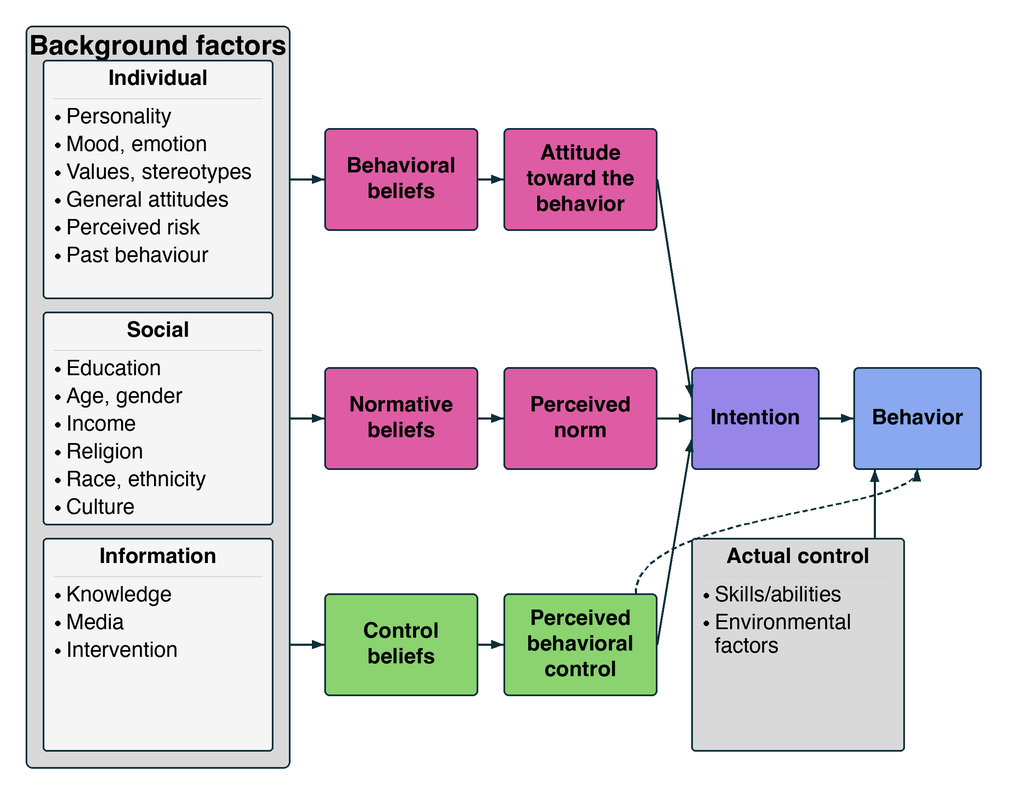

Source: Chapter 8, §8.4.3 and Figure 8.2

## Ask about the action, not just the problem

In the Thornapple survey, these are different questions:

| Question | What it helps us understand |
| --- | --- |
| Would mussels harm this lake? | General concern about the problem |
| Does draining my boat make a difference? | A belief about the benefit of draining |
| Do people I respect expect me to drain it? | Perceived social expectations |
| Can I drain it without making my group wait? | Perceived ability under these conditions |

Agreeing that mussels are harmful does not answer the other three.

Source: Chapter 8, §8.4.3 and Box 8.5; Friday Case Brief 07, Exhibit B

## What people do and what people expect

Two kinds of social norms can influence the same behavior:

### Descriptive norms

What others typically do.

“Most other boaters at this ramp drain their boats.”

### Injunctive norms

What others approve of or expect.

“People I respect expect me to drain my boat.”

A **personal norm** is one’s own sense of moral duty.

Source: Chapter 8, §8.3 and Box 8.1; Friday Case Brief 07, Exhibit B

## Intending to act is not the same as being able to

Among local boat anglers in this Friday’s case:

- 72% intend to drain before leaving on every trip next season.
- 29% believe they could drain without making their group wait.
- The north ramp has an 18-minute peak wait and no designated drain area.

Perceived control is a belief. Actual control also depends on skills and conditions.

Source: Chapter 8, Figure 8.2; Friday Case Brief 07, Exhibits B–C

## Choose a response that fits the evidence

If boaters doubt that draining helps, address that belief about the action.

If they think their group does not expect it, work with people whose approval matters to them.

If they do not know how to drain, teach the steps. If space or waiting time is the obstacle, change those conditions.

Source: Chapter 8, §8.4.3 and Figure 8.2; Friday Case Brief 07, Exhibits B–C and §7

## Collective action

Some conservation benefits depend on many people contributing.

What makes someone willing to do their part?

Source: Chapter 8, §8.4.2

## Why cooperation can be difficult

A **social dilemma** arises when actions that seem beneficial to each person produce a worse outcome for the group.

The chapter’s example: one household planting native vegetation may have a limited habitat effect; many participating households can provide greater benefits.

People weigh their costs, the shared benefit, and whether others will contribute. Someone may benefit while leaving the work to others: **free-riding**.

Incentives and group size can also affect participation.

Source: Chapter 8, §8.4.2 and §8.8

## Shared benefits and shared resources

### Public goods

It is difficult to exclude people from benefiting.

One person’s use does not reduce what is available to others.

### Common-pool resources

It is difficult to exclude people from using the resource.

Use can reduce what remains for others.

Both can require people to coordinate their actions.

Source: Chapter 8, §8.4.2 and §8.8

## Individual and collective influences

[figure not shown]

Source: Chapter 8, §8.4.2 and Box 8.4, Figure 1

## What the Montana bear study found

Researchers studied several ways landowners secure bear attractants, including garbage storage, bird feeder removal, and electric fencing.

- Different actions were associated with different individual factors.
- Collective factors mattered across the actions studied.
- Landowners who believed neighbors secured attractants, and expected them to continue, were **30%–100% more likely** to secure their own.

Source: Chapter 8, Box 8.4 and its Figure 1

## A perceived norm is not a behavior count

In this Friday’s survey, 22% of local anglers agreed:

> “Most other boaters at this ramp drain their boats.”

That is the share agreeing with a statement about others. It does **not** mean 22% of boats were observed draining.

Before claiming what most people do, collect evidence of what they actually do.

Source: Chapter 8, §8.3 and §8.4.2; Friday Case Brief 07, Exhibit B and §6

## Affect: emotions and behavior

[figure not shown]

Source: Chapter 8, §8.4.4

## Ask about the feeling and what brought it on

The chapter describes measuring responses to a particular stimulus with tools such as the **Discrete Emotions Questionnaire**.

A deer-management study found that emotions influenced which management options people considered acceptable.

In this Friday’s case, “I feel blamed” and “I feel worried about losing this fishery” ask about different emotional responses.

Source: Chapter 8, §8.4.4; Friday Case Brief 07, Exhibit B

## People can want different things from the same activity

The **multiple satisfaction approach** recognizes several benefits of hunting, fishing, and other wildlife activities:

- Affiliative: spending time with others and building relationships.
- Achievement: reaching a goal or testing one’s skill.
- Appreciative: enjoying nature, peace, or a sense of belonging.

A person may seek more than one benefit. Managing an experience requires more than setting a bag limit.

Source: Chapter 8, §8.4.5

## Desired experiences can help us understand different publics

The **recreation experience preference approach** measures the psychological outcomes people seek and considers how those preferences occur together.

**Specialization** describes a continuum from novice to expert, reflected in equipment, skill, knowledge, and commitment.

These approaches help identify shared goals and possible conflicts among users.

Source: Chapter 8, §8.4.5

## Self-determination theory

[figure not shown]

Source: Chapter 8, §8.4.5

## Motivation, experience, and satisfaction

[figure not shown]

Source: Chapter 8, §8.4.5

## What the satisfaction studies tell us

The chapter reports two findings:

- For anglers, catch rate, fish size, and harvest were the largest and most consistent determinants of satisfaction. Access and crowding were the strongest non-catch factors.
- For turkey hunters, achievement sometimes mattered more than appreciation or affiliation. Appreciation became relatively more important when hunters were unsuccessful.

Several benefits matter, but they do not always matter equally.

Source: Chapter 8, §8.4.5

## Choose the framework for the question

| Approach | Question |
| --- | --- |
| Cognitive hierarchy | How do broad values connect to a specific decision? |
| Reasoned action | What shapes intention, and what allows action? |
| Collective action | Why contribute to an outcome shared with others? |
| Affective approach | How do feelings shape a response or acceptance? |
| Motivation and satisfaction | What does someone seek, and what do they gain? |

A single conservation problem may need more than one approach.

Source: Chapter 8, §§8.4–8.5

## With a partner: explain the evidence

Use these comments from this Friday’s teaching case:

> “There’s a line of eight boats and a guy in a hurry behind me. I’m not holding that up for ten minutes.”

> “On the tournament circuit everybody decons. You’d get talked about if you didn’t.”

> “Every sign out here is written like we did something wrong.”

For each, name the concept, explain what the comment suggests, and propose a response. What would you still need to know?

Source: Chapter 8, §§8.4.2–8.4.5; Friday Case Brief 07, Exhibit D

## Measure the behavior you want to change

For draining, count whether boats perform the specified action before leaving.

A count of brochure pickups measures distribution. A reported intention measures readiness. Neither establishes that boats were drained.

Decide what result would lead you to change your response.

Source: Chapter 8, §8.4.3 and Box 8.5; Friday Case Brief 07, §6

## Preparing for this Friday, October 9

For **this Friday, October 9**, read the **Thornapple Lake Decontamination Problem** case brief before class.

Bring Chapter 8’s concepts. The brief supplies the scenario, survey, ramp audit, comments, strategies, costs, and monitoring options.

Your group will define the action, explain the evidence, and recommend a response within **$220,000**.

Source: Chapter 8, §§8.4–8.5; Friday Case Brief 07, §§6–8

## What would you change, and why?

Name the behavior, the evidence supporting your explanation, and the response that follows from it.

Then say what you would observe to find out whether the response helped.

Source: Chapter 8, §8.5

## Reference: the full Montana model

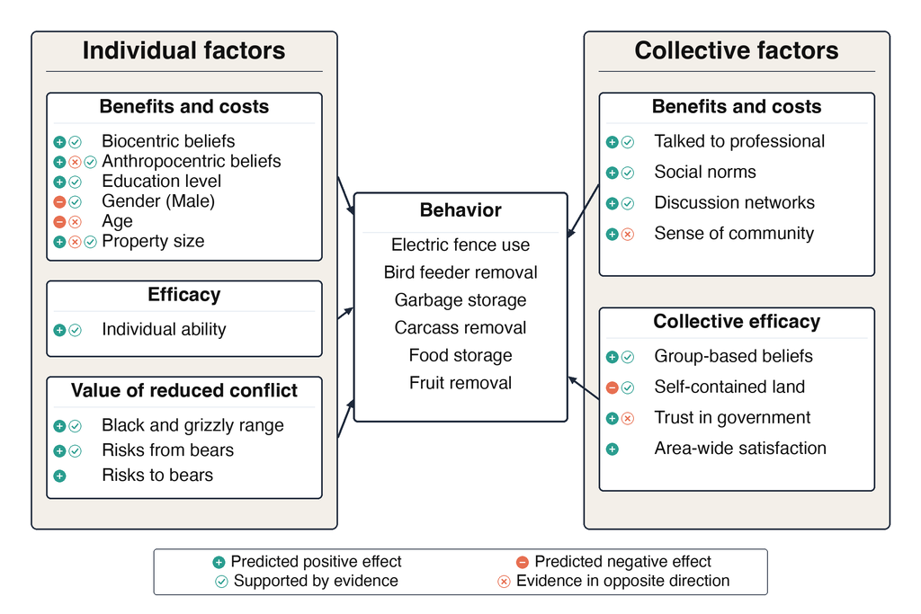

Source: Chapter 8, Box 8.4, Figure 1; manuscript figure-caption file, Figure 8.3

## Reference: four branches of psychology

- Cognitive psychology studies perception, reasoning, and decision-making.
- Social psychology studies how people and their social setting influence one another.
- Environmental psychology studies relationships between people and their surroundings.
- Conservation psychology applies psychological knowledge to healthy relationships between people and nature.

**Dual-process theory** distinguishes fast, intuitive processing (System 1) from slower, deliberate processing (System 2).

Source: Chapter 8, Box 8.1

## Reference: coexistence and disagreement

**Tolerance** means being willing to endure a species’ presence. **Acceptance** includes recognizing its value and actively supporting its presence or conservation.

In the Maine bear-hunting case, groups disagreed about whether baiting, hounding, and trapping were unethical or necessary for population management.

Those arguments involved beliefs and values as well as evaluations of particular practices.

Source: Chapter 8, §8.3 and Box 8.3

## Reference: support for salmon conservation was not enough

In the Downeast Maine aquaculture case, surveyed residents held positive attitudes toward salmon conservation and the proposed program.

The program later stalled amid inadequate agency communication and community engagement, and information from opponents.

Source: Chapter 8, Box 8.2 and §8.2.1